# EasyVisa Project

## Data Preprocessing

- Missing value treatment (if needed)
- Feature engineering
- Outlier detection and treatment (if needed)
- Preparing data for modeling
- Any other preprocessing steps (if needed)

```python
wages = {"Hour": 2080, "Week":52, "Month": 12, "Year":1}

data = data.replace(wages)
```

```python
data["prevailing_wage"] = data["prevailing_wage"].astype('int')
data["unit_of_wage"] = data["unit_of_wage"].astype('int')
data['annual_wage'] = data["unit_of_wage"] * data["prevailing_wage"]
data.head()
```

|  | continent | education_of_employee | has_job_experience | requires_job_training | no_of_employees | yr_of_estab | region_of_employment | prevailing_wage | unit_of_wage | full_time_position | case_status | annual_wage |
| --- | --- | --- | --- | --- | --- | --- | --- | --- | --- | --- | --- | --- |
| 0 | Asia | High School | N | N | 14513 | 2007 | West | 592 | 2080 | Y | 0 | 1231360 |
| 1 | Asia | Master's | Y | N | 2412 | 2002 | Northeast | 83425 | 1 | Y | 1 | 83425 |
| 2 | Asia | Bachelor's | N | Y | 44444 | 2008 | West | 122996 | 1 | Y | 0 | 122996 |
| 3 | Asia | Bachelor's | N | N | 98 | 1897 | West | 83434 | 1 | Y | 0 | 83434 |
| 4 | Africa | Master's | Y | N | 1082 | 2005 | South | 149907 | 1 | Y | 1 | 149907 |

Due to the different unit of wages, it would be easier to analyse the data and get a clear picture of wages acrossboard if we identify annual income across the different parameters.

I have assumed 8 hours of work a day, 5 working days a week and and 52 weeks a year and 12 months a year.

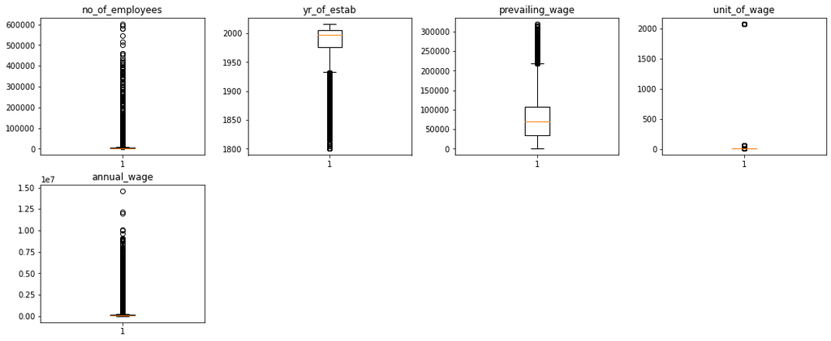

```python
numeric_columns = data.select_dtypes(include=np.number).columns.tolist()
numeric_columns.remove("case_status")

plt.figure(figsize=(15, 12))

for i, variable in enumerate(numeric_columns):
    plt.subplot(4, 4, i + 1)
    plt.boxplot(data[variable], whis=1.5)
    plt.tight_layout()
    plt.title(variable)

plt.show()
```

the outliers appear to be realistic figures so there is no need to treat them

## EDA

- It is a good idea to explore the data once again after manipulating it.

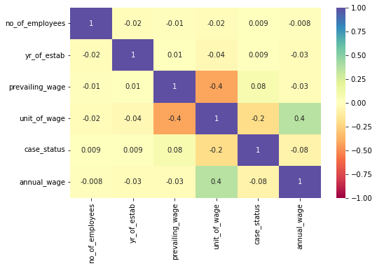

```python
plt.figure(figsize=(8,5))
sns.heatmap(data.corr(),annot=True,vmin=-1,vmax=1,fmt='.1g',cmap="Spectral")
plt.show()
```

## Building bagging and boosting models

```python
X = data.drop(["case_status"], axis=1)
y = data["case_status"]

X = pd.get_dummies(X, drop_first=True)

X_train, X_test, y_train, y_test = train_test_split(
    X, y, test_size=0.30, random_state=1,stratify=y)
```

```python
print("Shape of Training set : ", X_train.shape)
print("Shape of test set : ", X_test.shape)
print("Percentage of classes in training set:")
print(y_train.value_counts(normalize=True))
print("Percentage of classes in test set:")
print(y_test.value_counts(normalize=True))
```

```
Shape of Training set :  (17836, 20)
Shape of test set :  (7644, 20)
Percentage of classes in training set:
1    0.667919
0    0.332081
Name: case_status, dtype: float64
Percentage of classes in test set:
1    0.667844
0    0.332156
Name: case_status, dtype: float64
```

```python
def model_performance_classification_sklearn(model, predictors, target):

    pred = model.predict(predictors)

    acc = accuracy_score(target, pred)
    recall = recall_score(target, pred)
    precision = precision_score(target, pred)
    f1 = f1_score(target, pred)

    df_perf = pd.DataFrame(
        {
            "Accuracy": acc,
            "Recall": recall,
            "Precision": precision,
            "F1": f1,
        },
        index=[0],
    )

    return df_perf
```

```python
def confusion_matrix_sklearn(model, predictors, target):

    y_pred = model.predict(predictors)
    cm = confusion_matrix(target, y_pred)
    labels = np.asarray(
        [
            ["{0:0.0f}".format(item) + "\n{0:.2%}".format(item / cm.flatten().sum())]
            for item in cm.flatten()
        ]
    ).reshape(2, 2)

    plt.figure(figsize=(6, 4))
    sns.heatmap(cm, annot=labels, fmt="")
    plt.ylabel("True label")
    plt.xlabel("Predicted label")
```

```
Training performance:
    Accuracy  Recall  Precision   F1
0       1.0     1.0        1.0  1.0
Testing performance:
    Accuracy    Recall  Precision       F1
0  0.658032  0.740059   0.745903  0.74297
```

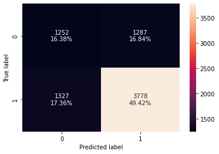

```python
d_tree = DecisionTreeClassifier(random_state=1)
d_tree.fit(X_train,y_train)

d_tree_model_train_perf=model_performance_classification_sklearn(d_tree,X_train,y_train)
print("Training performance:\n",d_tree_model_train_perf)
d_tree_model_test_perf=model_performance_classification_sklearn(d_tree,X_test,y_test)
print("Testing performance:\n",d_tree_model_test_perf)

confusion_matrix_sklearn(d_tree,X_test,y_test)
```

```python
dtree_estimator = DecisionTreeClassifier(class_weight={0:0.18,1:0.72},random_state=1)

parameters = {'max_depth': np.arange(2,30),
              'min_samples_leaf': [1, 2, 5, 7, 10],
              'max_leaf_nodes' : [2, 3, 5, 10,15],
              'min_impurity_decrease': [0.0001,0.001,0.01,0.1]
             }

scorer = metrics.make_scorer(metrics.f1_score)

grid_obj = GridSearchCV(dtree_estimator, parameters, scoring=scorer,n_jobs=-1)
grid_obj = grid_obj.fit(X_train, y_train)

dtree_estimator = grid_obj.best_estimator_

dtree_estimator.fit(X_train, y_train)
```

```
DecisionTreeClassifier(class_weight={0: 0.18, 1: 0.72}, max_depth=4,
                       max_leaf_nodes=15, min_impurity_decrease=0.0001,
                       random_state=1)
```

```
Training performance:
    Accuracy  Recall  Precision   F1
0       1.0     1.0        1.0  1.0
Testing performance:
    Accuracy    Recall  Precision       F1
0  0.658032  0.740059   0.745903  0.74297
```

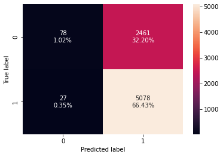

```python
dtree_estimator_model_train_perf=model_performance_classification_sklearn(d_tree,X_train,y_train)
print("Training performance:\n",dtree_estimator_model_train_perf)
dtree_estimator_model_test_perf=model_performance_classification_sklearn(d_tree,X_test,y_test)
print("Testing performance:\n",dtree_estimator_model_test_perf)

confusion_matrix_sklearn(dtree_estimator,X_test,y_test)
```

The decision tree is over fitting

```
Training performance:
    Accuracy  Recall  Precision   F1
0       1.0     1.0        1.0  1.0
Testing performance:
    Accuracy    Recall  Precision        F1
0  0.724097  0.838198   0.769328  0.802287
```

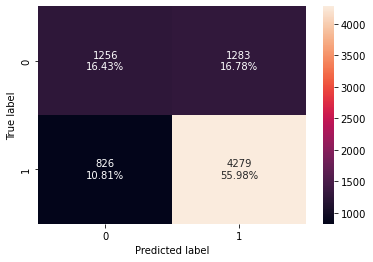

```python
rf_estimator = RandomForestClassifier(random_state=1)
rf_estimator.fit(X_train,y_train)

rf_estimator_model_train_perf=model_performance_classification_sklearn(rf_estimator,X_train,y_train)
print("Training performance:\n",rf_estimator_model_train_perf)
rf_estimator_model_test_perf=model_performance_classification_sklearn(rf_estimator,X_test,y_test)
print("Testing performance:\n",rf_estimator_model_test_perf)

confusion_matrix_sklearn(rf_estimator,X_test,y_test)
```

```python
rf_tuned = RandomForestClassifier(class_weight={0:0.18,1:0.82},random_state=1,oob_score=True,bootstrap=True)

parameters = {
                'max_depth': list(np.arange(5,30,5)) + [None],
                'max_features': ['sqrt','log2',None],
                'min_samples_leaf': np.arange(1,15,5),
                'min_samples_split': np.arange(2, 20, 5),
                'n_estimators': np.arange(10,110,10)}

scorer = metrics.make_scorer(metrics.f1_score)

grid_obj = GridSearchCV(rf_tuned, parameters, scoring=scorer, cv=5,n_jobs=-1)
grid_obj = grid_obj.fit(X_train, y_train)

rf_tuned = grid_obj.best_estimator_

rf_tuned.fit(X_train, y_train)
```

```
RandomForestClassifier(class_weight={0: 0.18, 1: 0.82}, max_features=None,
                       min_samples_leaf=6, min_samples_split=17,
                       n_estimators=50, oob_score=True, random_state=1)
```

```
Training performance:
    Accuracy    Recall  Precision        F1
0  0.776127  0.998153   0.749653  0.856238
Testing performance:
    Accuracy    Recall  Precision        F1
0   0.71337  0.955926   0.712825  0.816668
```

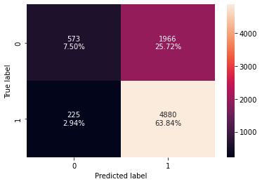

```python
rf_tuned_model_train_perf=model_performance_classification_sklearn(rf_tuned,X_train,y_train)
print("Training performance:\n",rf_tuned_model_train_perf)
rf_tuned_model_test_perf=model_performance_classification_sklearn(rf_tuned,X_test,y_test)
print("Testing performance:\n",rf_tuned_model_test_perf)

confusion_matrix_sklearn(rf_tuned,X_test,y_test)
```

Hyperparameter tuning was much more effective with the random forest.

The overfitting has been reduced and recall is very high

Bagging

```
   Accuracy    Recall  Precision        F1
0  0.984357  0.985646   0.990886  0.988259
   Accuracy    Recall  Precision        F1
0  0.693354  0.766699   0.772449  0.769564
```

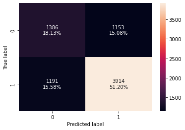

```python
bagging_classifier = BaggingClassifier(random_state=1)
bagging_classifier.fit(X_train,y_train)

bagging_classifier_model_train_perf=model_performance_classification_sklearn(bagging_classifier,X_train,y_train)
print(bagging_classifier_model_train_perf)
bagging_classifier_model_test_perf=model_performance_classification_sklearn(bagging_classifier,X_test,y_test)
print(bagging_classifier_model_test_perf)

confusion_matrix_sklearn(bagging_classifier,X_test,y_test)
```

```python
bagging_estimator_tuned = BaggingClassifier(random_state=1)

parameters = {'max_samples': [0.7,0.8,0.9,1],
              'max_features': [0.7,0.8,0.9,1],
              'n_estimators' : [10,20,30,40,50],
             }

scorer = metrics.make_scorer(metrics.f1_score)

grid_obj = GridSearchCV(bagging_estimator_tuned, parameters, scoring=scorer,cv=5)
grid_obj = grid_obj.fit(X_train, y_train)

bagging_estimator_tuned = grid_obj.best_estimator_

bagging_estimator_tuned.fit(X_train, y_train)
```

```
BaggingClassifier(max_features=0.8, max_samples=0.7, n_estimators=50,
                  random_state=1)
```

```
   Accuracy    Recall  Precision        F1
0  0.993272  0.997901   0.992072  0.994978
   Accuracy    Recall  Precision        F1
0  0.728545  0.860529   0.763204  0.808949
```

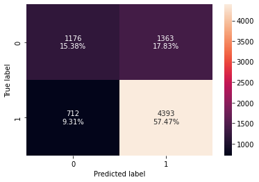

```python
bagging_estimator_tuned_model_train_perf=model_performance_classification_sklearn(bagging_estimator_tuned,X_train,y_train)
print(bagging_estimator_tuned_model_train_perf)
bagging_estimator_tuned_model_test_perf=model_performance_classification_sklearn(bagging_estimator_tuned,X_test,y_test)
print(bagging_estimator_tuned_model_test_perf)

confusion_matrix_sklearn(bagging_estimator_tuned,X_test,y_test)
```

The bagging classifier is overfitting.

After hyperparameter tuning, there was a bit of an improvement, but still overfitting.

FN improved from 15.5% to 9.3%.

AdaBoost Classifier

```
   Accuracy    Recall  Precision        F1
0  0.738058  0.887266   0.760486  0.818999
   Accuracy    Recall  Precision        F1
0  0.734171  0.884231   0.758018  0.816275
```

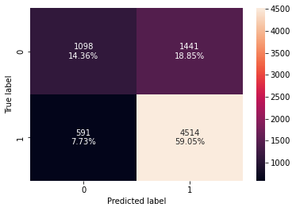

```python
ab_classifier = AdaBoostClassifier(random_state=1)
ab_classifier.fit(X_train,y_train)

ab_classifier_model_train_perf=model_performance_classification_sklearn(ab_classifier,X_train,y_train)
print(ab_classifier_model_train_perf)
ab_classifier_model_test_perf=model_performance_classification_sklearn(ab_classifier,X_test,y_test)
print(ab_classifier_model_test_perf)

confusion_matrix_sklearn(ab_classifier,X_test,y_test)
```

```python
abc_tuned = AdaBoostClassifier(random_state=1)

parameters = {

    "base_estimator":[DecisionTreeClassifier(max_depth=1),DecisionTreeClassifier(max_depth=2),
                      DecisionTreeClassifier(max_depth=3)],
    "n_estimators": np.arange(10,110,10),
    "learning_rate":np.arange(0.1,2,0.1)
}

scorer = metrics.make_scorer(metrics.f1_score)

grid_obj = GridSearchCV(abc_tuned, parameters, scoring=scorer,cv=5)
grid_obj = grid_obj.fit(X_train, y_train)

abc_tuned = grid_obj.best_estimator_

abc_tuned.fit(X_train, y_train)
```

```
AdaBoostClassifier(base_estimator=DecisionTreeClassifier(max_depth=3),
                   learning_rate=0.2, n_estimators=30, random_state=1)
```

```
   Accuracy    Recall  Precision        F1
0  0.755214  0.884496   0.778961  0.828381
   Accuracy   Recall  Precision        F1
0  0.741235  0.87855   0.767585  0.819328
```

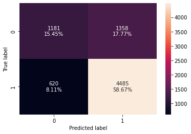

```python
abc_tuned_model_train_perf=model_performance_classification_sklearn(abc_tuned,X_train,y_train)
print(abc_tuned_model_train_perf)
abc_tuned_model_test_perf=model_performance_classification_sklearn(abc_tuned,X_test,y_test)
print(abc_tuned_model_test_perf)

confusion_matrix_sklearn(abc_tuned,X_test,y_test)
```

Gradient Boosting Classifier

```
Training performance:
    Accuracy    Recall  Precision        F1
0  0.759587  0.883237   0.784112  0.830728
Testing performance:
    Accuracy    Recall  Precision        F1
0  0.745552  0.874045   0.774115  0.821051
```

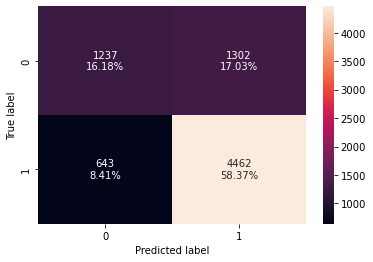

```python
gb_classifier = GradientBoostingClassifier(random_state=1)
gb_classifier.fit(X_train,y_train)

gb_classifier_model_train_perf=model_performance_classification_sklearn(gb_classifier,X_train,y_train)
print("Training performance:\n",gb_classifier_model_train_perf)
gb_classifier_model_test_perf=model_performance_classification_sklearn(gb_classifier,X_test,y_test)
print("Testing performance:\n",gb_classifier_model_test_perf)

confusion_matrix_sklearn(gb_classifier,X_test,y_test)
```

```python
gbc_tuned = GradientBoostingClassifier(init=AdaBoostClassifier(random_state=1),random_state=1)

parameters = {
    "n_estimators": [100,150,200,250],
    "subsample":[0.8,0.9,1],
    "max_features":[0.7,0.8,0.9,1]
}

scorer = metrics.make_scorer(metrics.f1_score)

# Run the grid search
grid_obj = GridSearchCV(gbc_tuned, parameters, scoring=scorer,cv=5)
grid_obj = grid_obj.fit(X_train, y_train)

# Set the clf to the best combination of parameters
gbc_tuned = grid_obj.best_estimator_

# Fit the best algorithm to the data.
gbc_tuned.fit(X_train, y_train)
```

```
GradientBoostingClassifier(init=AdaBoostClassifier(random_state=1),
                           max_features=0.9, random_state=1, subsample=0.8)
```